# Risk Factor Analysis

## Outcome Variable

**Outcome Variable:** swasted

## Predictor Variables

**Intervention Variable:** mhtcm

**Adjustment Set:**

unadjusted

## Stratifying Variables

The analysis was stratified on these variable(s):

- agecat
- studyid
- country

## Data Summary

| agecat | studyid | country | mhtcm | swasted | n_cell | n |
| --- | --- | --- | --- | --- | --- | --- |
| Birth | COHORTS | GUATEMALA | >=155 cm | 0 | 90 | 748 |
| Birth | COHORTS | GUATEMALA | >=155 cm | 1 | 13 | 748 |
| Birth | COHORTS | GUATEMALA | <151 cm | 0 | 447 | 748 |
| Birth | COHORTS | GUATEMALA | <151 cm | 1 | 37 | 748 |
| Birth | COHORTS | GUATEMALA | [151-155) cm | 0 | 151 | 748 |
| Birth | COHORTS | GUATEMALA | [151-155) cm | 1 | 10 | 748 |
| Birth | COHORTS | INDIA | >=155 cm | 0 | 480 | 1676 |
| Birth | COHORTS | INDIA | >=155 cm | 1 | 28 | 1676 |
| Birth | COHORTS | INDIA | <151 cm | 0 | 677 | 1676 |
| Birth | COHORTS | INDIA | <151 cm | 1 | 35 | 1676 |
| Birth | COHORTS | INDIA | [151-155) cm | 0 | 437 | 1676 |
| Birth | COHORTS | INDIA | [151-155) cm | 1 | 19 | 1676 |
| Birth | COHORTS | PHILIPPINES | >=155 cm | 0 | 592 | 2899 |
| Birth | COHORTS | PHILIPPINES | >=155 cm | 1 | 24 | 2899 |
| Birth | COHORTS | PHILIPPINES | <151 cm | 0 | 1383 | 2899 |
| Birth | COHORTS | PHILIPPINES | <151 cm | 1 | 62 | 2899 |
| Birth | COHORTS | PHILIPPINES | [151-155) cm | 0 | 803 | 2899 |
| Birth | COHORTS | PHILIPPINES | [151-155) cm | 1 | 35 | 2899 |
| Birth | JiVitA-3 | BANGLADESH | >=155 cm | 0 | 2914 | 17936 |
| Birth | JiVitA-3 | BANGLADESH | >=155 cm | 1 | 52 | 17936 |
| Birth | JiVitA-3 | BANGLADESH | <151 cm | 0 | 10048 | 17936 |
| Birth | JiVitA-3 | BANGLADESH | <151 cm | 1 | 211 | 17936 |
| Birth | JiVitA-3 | BANGLADESH | [151-155) cm | 0 | 4627 | 17936 |
| Birth | JiVitA-3 | BANGLADESH | [151-155) cm | 1 | 84 | 17936 |
| Birth | Keneba | GAMBIA | >=155 cm | 0 | 1061 | 1362 |
| Birth | Keneba | GAMBIA | >=155 cm | 1 | 74 | 1362 |
| Birth | Keneba | GAMBIA | <151 cm | 0 | 42 | 1362 |
| Birth | Keneba | GAMBIA | <151 cm | 1 | 4 | 1362 |
| Birth | Keneba | GAMBIA | [151-155) cm | 0 | 161 | 1362 |
| Birth | Keneba | GAMBIA | [151-155) cm | 1 | 20 | 1362 |

[output cut: 324 more lines]

The following strata were considered:

- agecat: 24 months, studyid: COHORTS, country: GUATEMALA
- agecat: 24 months, studyid: COHORTS, country: INDIA
- agecat: 24 months, studyid: COHORTS, country: PHILIPPINES
- agecat: 24 months, studyid: JiVitA-3, country: BANGLADESH
- agecat: 24 months, studyid: Keneba, country: GAMBIA
- agecat: 24 months, studyid: LCNI-5, country: MALAWI
- agecat: 24 months, studyid: MAL-ED, country: BANGLADESH
- agecat: 24 months, studyid: MAL-ED, country: BRAZIL
- agecat: 24 months, studyid: MAL-ED, country: INDIA
- agecat: 24 months, studyid: MAL-ED, country: NEPAL
- agecat: 24 months, studyid: MAL-ED, country: PERU
- agecat: 24 months, studyid: MAL-ED, country: SOUTH AFRICA
- agecat: 24 months, studyid: MAL-ED, country: TANZANIA, UNITED REPUBLIC OF
- agecat: 24 months, studyid: NIH-Birth, country: BANGLADESH
- agecat: 24 months, studyid: NIH-Crypto, country: BANGLADESH
- agecat: 24 months, studyid: PROBIT, country: BELARUS
- agecat: 24 months, studyid: PROVIDE, country: BANGLADESH
- agecat: 24 months, studyid: TanzaniaChild2, country: TANZANIA, UNITED REPUBLIC OF
- agecat: 24 months, studyid: ZVITAMBO, country: ZIMBABWE
- agecat: 6 months, studyid: COHORTS, country: GUATEMALA
- agecat: 6 months, studyid: COHORTS, country: INDIA
- agecat: 6 months, studyid: COHORTS, country: PHILIPPINES
- agecat: 6 months, studyid: Guatemala BSC, country: GUATEMALA
- agecat: 6 months, studyid: JiVitA-3, country: BANGLADESH
- agecat: 6 months, studyid: Keneba, country: GAMBIA
- agecat: 6 months, studyid: LCNI-5, country: MALAWI
- agecat: 6 months, studyid: MAL-ED, country: BANGLADESH
- agecat: 6 months, studyid: MAL-ED, country: BRAZIL
- agecat: 6 months, studyid: MAL-ED, country: INDIA
- agecat: 6 months, studyid: MAL-ED, country: NEPAL
- agecat: 6 months, studyid: MAL-ED, country: PERU
- agecat: 6 months, studyid: MAL-ED, country: SOUTH AFRICA
- agecat: 6 months, studyid: MAL-ED, country: TANZANIA, UNITED REPUBLIC OF
- agecat: 6 months, studyid: NIH-Birth, country: BANGLADESH
- agecat: 6 months, studyid: NIH-Crypto, country: BANGLADESH
- agecat: 6 months, studyid: PROBIT, country: BELARUS
- agecat: 6 months, studyid: PROVIDE, country: BANGLADESH
- agecat: 6 months, studyid: SAS-CompFeed, country: INDIA
- agecat: 6 months, studyid: SAS-FoodSuppl, country: INDIA
- agecat: 6 months, studyid: TanzaniaChild2, country: TANZANIA, UNITED REPUBLIC OF
- agecat: 6 months, studyid: ZVITAMBO, country: ZIMBABWE
- agecat: Birth, studyid: COHORTS, country: GUATEMALA
- agecat: Birth, studyid: COHORTS, country: INDIA
- agecat: Birth, studyid: COHORTS, country: PHILIPPINES
- agecat: Birth, studyid: JiVitA-3, country: BANGLADESH
- agecat: Birth, studyid: Keneba, country: GAMBIA
- agecat: Birth, studyid: MAL-ED, country: BANGLADESH
- agecat: Birth, studyid: MAL-ED, country: BRAZIL
- agecat: Birth, studyid: MAL-ED, country: INDIA
- agecat: Birth, studyid: MAL-ED, country: NEPAL
- agecat: Birth, studyid: MAL-ED, country: PERU
- agecat: Birth, studyid: MAL-ED, country: SOUTH AFRICA
- agecat: Birth, studyid: MAL-ED, country: TANZANIA, UNITED REPUBLIC OF
- agecat: Birth, studyid: NIH-Birth, country: BANGLADESH
- agecat: Birth, studyid: NIH-Crypto, country: BANGLADESH
- agecat: Birth, studyid: PROBIT, country: BELARUS
- agecat: Birth, studyid: PROVIDE, country: BANGLADESH
- agecat: Birth, studyid: SAS-CompFeed, country: INDIA
- agecat: Birth, studyid: ZVITAMBO, country: ZIMBABWE

### Dropped Strata

Some strata were dropped due to rare outcomes:

- agecat: Birth, studyid: Keneba, country: GAMBIA
- agecat: Birth, studyid: MAL-ED, country: BANGLADESH
- agecat: Birth, studyid: MAL-ED, country: BRAZIL
- agecat: Birth, studyid: MAL-ED, country: INDIA
- agecat: Birth, studyid: MAL-ED, country: NEPAL
- agecat: Birth, studyid: MAL-ED, country: PERU
- agecat: Birth, studyid: MAL-ED, country: SOUTH AFRICA
- agecat: Birth, studyid: MAL-ED, country: TANZANIA, UNITED REPUBLIC OF
- agecat: Birth, studyid: NIH-Birth, country: BANGLADESH
- agecat: Birth, studyid: PROVIDE, country: BANGLADESH
- agecat: 6 months, studyid: COHORTS, country: GUATEMALA
- agecat: 6 months, studyid: Guatemala BSC, country: GUATEMALA
- agecat: 6 months, studyid: Keneba, country: GAMBIA
- agecat: 6 months, studyid: LCNI-5, country: MALAWI
- agecat: 6 months, studyid: MAL-ED, country: BANGLADESH
- agecat: 6 months, studyid: MAL-ED, country: BRAZIL
- agecat: 6 months, studyid: MAL-ED, country: INDIA
- agecat: 6 months, studyid: MAL-ED, country: NEPAL
- agecat: 6 months, studyid: MAL-ED, country: PERU
- agecat: 6 months, studyid: MAL-ED, country: SOUTH AFRICA
- agecat: 6 months, studyid: MAL-ED, country: TANZANIA, UNITED REPUBLIC OF
- agecat: 6 months, studyid: NIH-Birth, country: BANGLADESH
- agecat: 6 months, studyid: NIH-Crypto, country: BANGLADESH
- agecat: 6 months, studyid: PROBIT, country: BELARUS
- agecat: 6 months, studyid: PROVIDE, country: BANGLADESH
- agecat: 6 months, studyid: SAS-FoodSuppl, country: INDIA
- agecat: 6 months, studyid: TanzaniaChild2, country: TANZANIA, UNITED REPUBLIC OF
- agecat: 24 months, studyid: COHORTS, country: GUATEMALA
- agecat: 24 months, studyid: COHORTS, country: INDIA
- agecat: 24 months, studyid: COHORTS, country: PHILIPPINES
- agecat: 24 months, studyid: Keneba, country: GAMBIA
- agecat: 24 months, studyid: LCNI-5, country: MALAWI
- agecat: 24 months, studyid: MAL-ED, country: BANGLADESH
- agecat: 24 months, studyid: MAL-ED, country: BRAZIL
- agecat: 24 months, studyid: MAL-ED, country: INDIA
- agecat: 24 months, studyid: MAL-ED, country: NEPAL
- agecat: 24 months, studyid: MAL-ED, country: PERU
- agecat: 24 months, studyid: MAL-ED, country: SOUTH AFRICA
- agecat: 24 months, studyid: MAL-ED, country: TANZANIA, UNITED REPUBLIC OF
- agecat: 24 months, studyid: NIH-Birth, country: BANGLADESH
- agecat: 24 months, studyid: NIH-Crypto, country: BANGLADESH
- agecat: 24 months, studyid: PROBIT, country: BELARUS
- agecat: 24 months, studyid: PROVIDE, country: BANGLADESH
- agecat: 24 months, studyid: TanzaniaChild2, country: TANZANIA, UNITED REPUBLIC OF
- agecat: 24 months, studyid: ZVITAMBO, country: ZIMBABWE

## Methods Detail

We’re interested in the causal parameters $E[Y_a]$ for all values of $a \in \mathcal{A}$. These parameters represent the mean outcome if, possibly contrary to fact, we intervened to set all units to have $A=a$. Under the randomization and positivity assumptions, these are identified by the statistical parameters $\psi_a=E_W[E_{Y|A,W}(Y|A=a,W)]$. In addition, we’re interested in the mean of $Y$, $E[Y]$ under no intervention (the observed mean). We will estimate these parameters by using SuperLearner to fit the relevant likelihood factors – $E_{Y|A,W}(Y|A=a,W)$ and $p(A=a|W)$, and then updating our likelihood fit using a joint TMLE.

For unadjusted analyses ($W=\{\}$), initial likelihoods were estimated using Lrnr_glm to estimate the simple $E(Y|A)$ and Lrnr_mean to estimate $p(A)$. For adjusted analyses, a small library containing Lrnr_glmnet, Lrnr_xgboost, and Lrnr_mean was used.

Having estimated these parameters, we will then use the delta method to estimate relative risks and attributable risks relative to a prespecified baseline level of $A$.

# Results Detail

## Results Plots

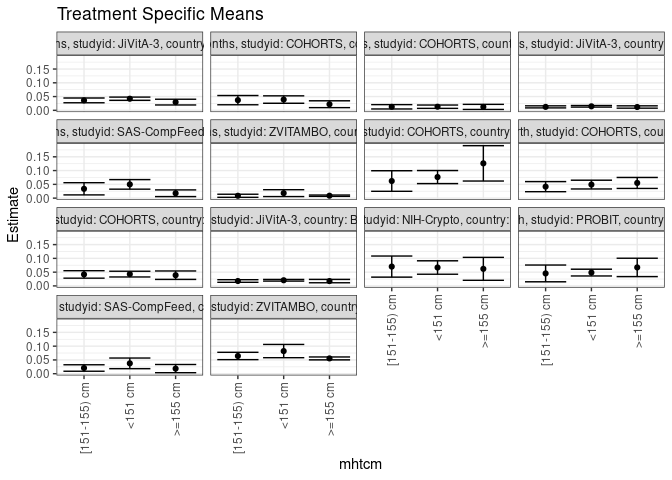

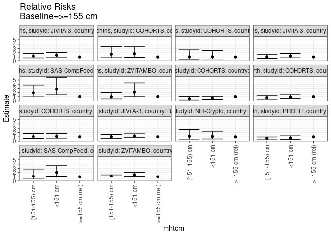

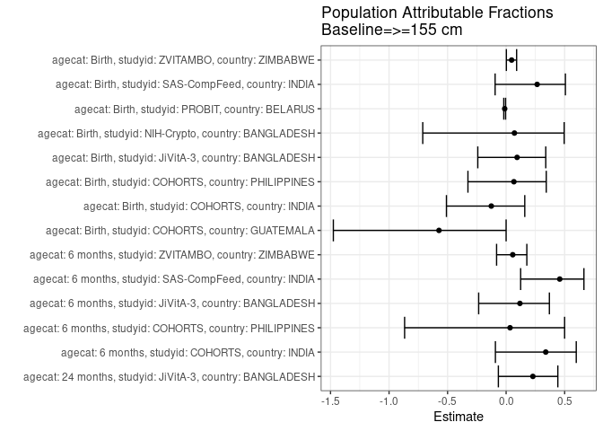

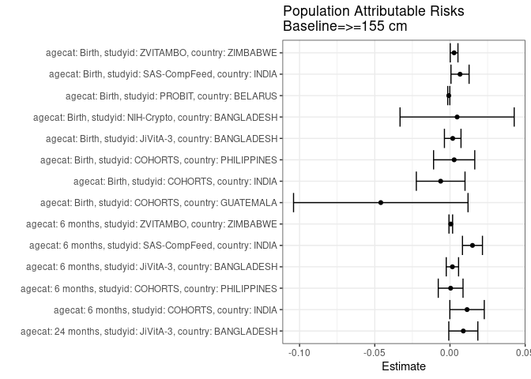

## Results Table

### Parameter: TSM

| agecat | studyid | country | intervention_level | baseline_level | estimate | ci_lower | ci_upper |
| --- | --- | --- | --- | --- | --- | --- | --- |
| Birth | COHORTS | GUATEMALA | >=155 cm | NA | 0.1262136 | 0.0620371 | 0.1903900 |
| Birth | COHORTS | GUATEMALA | <151 cm | NA | 0.0764463 | 0.0527585 | 0.1001341 |
| Birth | COHORTS | GUATEMALA | [151-155) cm | NA | 0.0621118 | 0.0248050 | 0.0994186 |
| Birth | COHORTS | INDIA | >=155 cm | NA | 0.0551181 | 0.0352671 | 0.0749691 |
| Birth | COHORTS | INDIA | <151 cm | NA | 0.0491573 | 0.0332723 | 0.0650423 |
| Birth | COHORTS | INDIA | [151-155) cm | NA | 0.0416667 | 0.0233204 | 0.0600129 |
| Birth | COHORTS | PHILIPPINES | >=155 cm | NA | 0.0389610 | 0.0236777 | 0.0542444 |
| Birth | COHORTS | PHILIPPINES | <151 cm | NA | 0.0429066 | 0.0324563 | 0.0533569 |
| Birth | COHORTS | PHILIPPINES | [151-155) cm | NA | 0.0417661 | 0.0282189 | 0.0553133 |
| Birth | JiVitA-3 | BANGLADESH | >=155 cm | NA | 0.0175320 | 0.0113951 | 0.0236690 |
| Birth | JiVitA-3 | BANGLADESH | <151 cm | NA | 0.0205673 | 0.0175715 | 0.0235632 |
| Birth | JiVitA-3 | BANGLADESH | [151-155) cm | NA | 0.0178306 | 0.0130644 | 0.0225968 |
| Birth | NIH-Crypto | BANGLADESH | >=155 cm | NA | 0.0620155 | 0.0203660 | 0.1036650 |
| Birth | NIH-Crypto | BANGLADESH | <151 cm | NA | 0.0668317 | 0.0424627 | 0.0912007 |
| Birth | NIH-Crypto | BANGLADESH | [151-155) cm | NA | 0.0701754 | 0.0318619 | 0.1084889 |
| Birth | PROBIT | BELARUS | >=155 cm | NA | 0.0671437 | 0.0337858 | 0.1005016 |
| Birth | PROBIT | BELARUS | <151 cm | NA | 0.0483871 | 0.0361204 | 0.0606538 |
| Birth | PROBIT | BELARUS | [151-155) cm | NA | 0.0453401 | 0.0149470 | 0.0757331 |
| Birth | SAS-CompFeed | INDIA | >=155 cm | NA | 0.0185185 | 0.0036666 | 0.0333705 |
| Birth | SAS-CompFeed | INDIA | <151 cm | NA | 0.0376176 | 0.0183457 | 0.0568894 |
| Birth | SAS-CompFeed | INDIA | [151-155) cm | NA | 0.0207469 | 0.0089754 | 0.0325184 |
| Birth | ZVITAMBO | ZIMBABWE | >=155 cm | NA | 0.0555402 | 0.0502701 | 0.0608103 |
| Birth | ZVITAMBO | ZIMBABWE | <151 cm | NA | 0.0821643 | 0.0580683 | 0.1062604 |
| Birth | ZVITAMBO | ZIMBABWE | [151-155) cm | NA | 0.0643678 | 0.0510524 | 0.0776832 |
| 6 months | COHORTS | INDIA | >=155 cm | NA | 0.0221811 | 0.0097678 | 0.0345945 |
| 6 months | COHORTS | INDIA | <151 cm | NA | 0.0391909 | 0.0256642 | 0.0527176 |
| 6 months | COHORTS | INDIA | [151-155) cm | NA | 0.0369610 | 0.0202001 | 0.0537219 |
| 6 months | COHORTS | PHILIPPINES | >=155 cm | NA | 0.0125000 | 0.0032964 | 0.0217036 |
| 6 months | COHORTS | PHILIPPINES | <151 cm | NA | 0.0131579 | 0.0071184 | 0.0191974 |
| 6 months | COHORTS | PHILIPPINES | [151-155) cm | NA | 0.0128535 | 0.0049369 | 0.0207701 |
| 6 months | JiVitA-3 | BANGLADESH | >=155 cm | NA | 0.0120709 | 0.0078611 | 0.0162807 |
| 6 months | JiVitA-3 | BANGLADESH | <151 cm | NA | 0.0146112 | 0.0117262 | 0.0174963 |
| 6 months | JiVitA-3 | BANGLADESH | [151-155) cm | NA | 0.0125698 | 0.0088338 | 0.0163058 |
| 6 months | SAS-CompFeed | INDIA | >=155 cm | NA | 0.0176817 | 0.0055394 | 0.0298241 |
| 6 months | SAS-CompFeed | INDIA | <151 cm | NA | 0.0498812 | 0.0325212 | 0.0672413 |
| 6 months | SAS-CompFeed | INDIA | [151-155) cm | NA | 0.0337838 | 0.0116352 | 0.0559323 |
| 6 months | ZVITAMBO | ZIMBABWE | >=155 cm | NA | 0.0088235 | 0.0064125 | 0.0112346 |
| 6 months | ZVITAMBO | ZIMBABWE | <151 cm | NA | 0.0181818 | 0.0056969 | 0.0306667 |
| 6 months | ZVITAMBO | ZIMBABWE | [151-155) cm | NA | 0.0085714 | 0.0029952 | 0.0141477 |
| 24 months | JiVitA-3 | BANGLADESH | >=155 cm | NA | 0.0298851 | 0.0194685 | 0.0403017 |
| 24 months | JiVitA-3 | BANGLADESH | <151 cm | NA | 0.0421615 | 0.0363326 | 0.0479904 |
| 24 months | JiVitA-3 | BANGLADESH | [151-155) cm | NA | 0.0361500 | 0.0274975 | 0.0448025 |

### Parameter: E(Y)

| agecat | studyid | country | intervention_level | baseline_level | estimate | ci_lower | ci_upper |
| --- | --- | --- | --- | --- | --- | --- | --- |
| Birth | COHORTS | GUATEMALA | NA | NA | 0.0802139 | 0.0607354 | 0.0996924 |
| Birth | COHORTS | INDIA | NA | NA | 0.0489260 | 0.0385956 | 0.0592564 |
| Birth | COHORTS | PHILIPPINES | NA | NA | 0.0417385 | 0.0344572 | 0.0490198 |
| Birth | JiVitA-3 | BANGLADESH | NA | NA | 0.0193466 | 0.0169070 | 0.0217861 |
| Birth | NIH-Crypto | BANGLADESH | NA | NA | 0.0667614 | 0.0483100 | 0.0852128 |
| Birth | PROBIT | BELARUS | NA | NA | 0.0663396 | 0.0334725 | 0.0992067 |
| Birth | SAS-CompFeed | INDIA | NA | NA | 0.0252016 | 0.0126376 | 0.0377656 |
| Birth | ZVITAMBO | ZIMBABWE | NA | NA | 0.0582781 | 0.0534540 | 0.0631023 |
| 6 months | COHORTS | INDIA | NA | NA | 0.0335349 | 0.0252594 | 0.0418104 |
| 6 months | COHORTS | PHILIPPINES | NA | NA | 0.0129342 | 0.0086762 | 0.0171922 |
| 6 months | JiVitA-3 | BANGLADESH | NA | NA | 0.0136847 | 0.0116040 | 0.0157654 |
| 6 months | SAS-CompFeed | INDIA | NA | NA | 0.0326264 | 0.0237765 | 0.0414763 |
| 6 months | ZVITAMBO | ZIMBABWE | NA | NA | 0.0093535 | 0.0071406 | 0.0115664 |
| 24 months | JiVitA-3 | BANGLADESH | NA | NA | 0.0387398 | 0.0343960 | 0.0430836 |

### Parameter: RR

| agecat | studyid | country | intervention_level | baseline_level | estimate | ci_lower | ci_upper |
| --- | --- | --- | --- | --- | --- | --- | --- |
| Birth | COHORTS | GUATEMALA | >=155 cm | >=155 cm | 1.0000000 | 1.0000000 | 1.0000000 |
| Birth | COHORTS | GUATEMALA | <151 cm | >=155 cm | 0.6056898 | 0.3339253 | 1.0986292 |
| Birth | COHORTS | GUATEMALA | [151-155) cm | >=155 cm | 0.4921166 | 0.2240233 | 1.0810427 |
| Birth | COHORTS | INDIA | >=155 cm | >=155 cm | 1.0000000 | 1.0000000 | 1.0000000 |
| Birth | COHORTS | INDIA | <151 cm | >=155 cm | 0.8918539 | 0.5497310 | 1.4468958 |
| Birth | COHORTS | INDIA | [151-155) cm | >=155 cm | 0.7559524 | 0.4280046 | 1.3351818 |
| Birth | COHORTS | PHILIPPINES | >=155 cm | >=155 cm | 1.0000000 | 1.0000000 | 1.0000000 |
| Birth | COHORTS | PHILIPPINES | <151 cm | >=155 cm | 1.1012687 | 0.6940081 | 1.7475196 |
| Birth | COHORTS | PHILIPPINES | [151-155) cm | >=155 cm | 1.0719968 | 0.6443703 | 1.7834112 |
| Birth | JiVitA-3 | BANGLADESH | >=155 cm | >=155 cm | 1.0000000 | 1.0000000 | 1.0000000 |
| Birth | JiVitA-3 | BANGLADESH | <151 cm | >=155 cm | 1.1731275 | 0.8055455 | 1.7084425 |
| Birth | JiVitA-3 | BANGLADESH | [151-155) cm | >=155 cm | 1.0170305 | 0.6575314 | 1.5730823 |
| Birth | NIH-Crypto | BANGLADESH | >=155 cm | >=155 cm | 1.0000000 | 1.0000000 | 1.0000000 |
| Birth | NIH-Crypto | BANGLADESH | <151 cm | >=155 cm | 1.0776609 | 0.5018738 | 2.3140340 |
| Birth | NIH-Crypto | BANGLADESH | [151-155) cm | >=155 cm | 1.1315789 | 0.4762055 | 2.6889043 |
| Birth | PROBIT | BELARUS | >=155 cm | >=155 cm | 1.0000000 | 1.0000000 | 1.0000000 |
| Birth | PROBIT | BELARUS | <151 cm | >=155 cm | 0.7206496 | 0.4227919 | 1.2283483 |
| Birth | PROBIT | BELARUS | [151-155) cm | >=155 cm | 0.6752686 | 0.4717891 | 0.9665074 |
| Birth | SAS-CompFeed | INDIA | >=155 cm | >=155 cm | 1.0000000 | 1.0000000 | 1.0000000 |
| Birth | SAS-CompFeed | INDIA | <151 cm | >=155 cm | 2.0313480 | 1.1392131 | 3.6221271 |
| Birth | SAS-CompFeed | INDIA | [151-155) cm | >=155 cm | 1.1203320 | 0.4420816 | 2.8391675 |
| Birth | ZVITAMBO | ZIMBABWE | >=155 cm | >=155 cm | 1.0000000 | 1.0000000 | 1.0000000 |
| Birth | ZVITAMBO | ZIMBABWE | <151 cm | >=155 cm | 1.4793657 | 1.0869527 | 2.0134481 |
| Birth | ZVITAMBO | ZIMBABWE | [151-155) cm | >=155 cm | 1.1589401 | 0.9230402 | 1.4551286 |
| 6 months | COHORTS | INDIA | >=155 cm | >=155 cm | 1.0000000 | 1.0000000 | 1.0000000 |
| 6 months | COHORTS | INDIA | <151 cm | >=155 cm | 1.7668563 | 0.9154782 | 3.4100005 |
| 6 months | COHORTS | INDIA | [151-155) cm | >=155 cm | 1.6663244 | 0.8108437 | 3.4243804 |
| 6 months | COHORTS | PHILIPPINES | >=155 cm | >=155 cm | 1.0000000 | 1.0000000 | 1.0000000 |
| 6 months | COHORTS | PHILIPPINES | <151 cm | >=155 cm | 1.0526316 | 0.4420422 | 2.5066230 |
| 6 months | COHORTS | PHILIPPINES | [151-155) cm | >=155 cm | 1.0282776 | 0.3937471 | 2.6853657 |
| 6 months | JiVitA-3 | BANGLADESH | >=155 cm | >=155 cm | 1.0000000 | 1.0000000 | 1.0000000 |
| 6 months | JiVitA-3 | BANGLADESH | <151 cm | >=155 cm | 1.2104482 | 0.8069403 | 1.8157289 |
| 6 months | JiVitA-3 | BANGLADESH | [151-155) cm | >=155 cm | 1.0413321 | 0.6591090 | 1.6452097 |
| 6 months | SAS-CompFeed | INDIA | >=155 cm | >=155 cm | 1.0000000 | 1.0000000 | 1.0000000 |
| 6 months | SAS-CompFeed | INDIA | <151 cm | >=155 cm | 2.8210610 | 1.4369308 | 5.5384607 |
| 6 months | SAS-CompFeed | INDIA | [151-155) cm | >=155 cm | 1.9106607 | 0.9555150 | 3.8205828 |
| 6 months | ZVITAMBO | ZIMBABWE | >=155 cm | >=155 cm | 1.0000000 | 1.0000000 | 1.0000000 |
| 6 months | ZVITAMBO | ZIMBABWE | <151 cm | >=155 cm | 2.0606061 | 0.9840848 | 4.3147675 |
| 6 months | ZVITAMBO | ZIMBABWE | [151-155) cm | >=155 cm | 0.9714286 | 0.4796946 | 1.9672380 |
| 24 months | JiVitA-3 | BANGLADESH | >=155 cm | >=155 cm | 1.0000000 | 1.0000000 | 1.0000000 |
| 24 months | JiVitA-3 | BANGLADESH | <151 cm | >=155 cm | 1.4107893 | 0.9750690 | 2.0412162 |
| 24 months | JiVitA-3 | BANGLADESH | [151-155) cm | >=155 cm | 1.2096354 | 0.7853881 | 1.8630506 |

### Parameter: PAR

| agecat | studyid | country | intervention_level | baseline_level | estimate | ci_lower | ci_upper |
| --- | --- | --- | --- | --- | --- | --- | --- |
| Birth | COHORTS | GUATEMALA | >=155 cm | NA | -0.0459997 | -0.1039976 | 0.0119982 |
| Birth | COHORTS | INDIA | >=155 cm | NA | -0.0061921 | -0.0223753 | 0.0099911 |
| Birth | COHORTS | PHILIPPINES | >=155 cm | NA | 0.0027775 | -0.0109095 | 0.0164644 |
| Birth | JiVitA-3 | BANGLADESH | >=155 cm | NA | 0.0018145 | -0.0036936 | 0.0073227 |
| Birth | NIH-Crypto | BANGLADESH | >=155 cm | NA | 0.0047459 | -0.0331938 | 0.0426855 |
| Birth | PROBIT | BELARUS | >=155 cm | NA | -0.0008041 | -0.0015093 | -0.0000989 |
| Birth | SAS-CompFeed | INDIA | >=155 cm | NA | 0.0066831 | 0.0006691 | 0.0126971 |
| Birth | ZVITAMBO | ZIMBABWE | >=155 cm | NA | 0.0027379 | 0.0001768 | 0.0052990 |
| 6 months | COHORTS | INDIA | >=155 cm | NA | 0.0113538 | -0.0000881 | 0.0227956 |
| 6 months | COHORTS | PHILIPPINES | >=155 cm | NA | 0.0004342 | -0.0077985 | 0.0086669 |
| 6 months | JiVitA-3 | BANGLADESH | >=155 cm | NA | 0.0016138 | -0.0024847 | 0.0057123 |
| 6 months | SAS-CompFeed | INDIA | >=155 cm | NA | 0.0149447 | 0.0082992 | 0.0215902 |
| 6 months | ZVITAMBO | ZIMBABWE | >=155 cm | NA | 0.0005300 | -0.0006810 | 0.0017409 |
| 24 months | JiVitA-3 | BANGLADESH | >=155 cm | NA | 0.0088547 | -0.0008075 | 0.0185170 |

### Parameter: PAF

| agecat | studyid | country | intervention_level | baseline_level | estimate | ci_lower | ci_upper |
| --- | --- | --- | --- | --- | --- | --- | --- |
| Birth | COHORTS | GUATEMALA | >=155 cm | NA | -0.5734628 | -1.4758280 | 0.0000173 |
| Birth | COHORTS | INDIA | >=155 cm | NA | -0.1265604 | -0.5097297 | 0.1593606 |
| Birth | COHORTS | PHILIPPINES | >=155 cm | NA | 0.0665450 | -0.3260881 | 0.3429259 |
| Birth | JiVitA-3 | BANGLADESH | >=155 cm | NA | 0.0937911 | -0.2418788 | 0.3387321 |
| Birth | NIH-Crypto | BANGLADESH | >=155 cm | NA | 0.0710869 | -0.7120973 | 0.4960102 |
| Birth | PROBIT | BELARUS | >=155 cm | NA | -0.0121213 | -0.0199560 | -0.0043467 |
| Birth | SAS-CompFeed | INDIA | >=155 cm | NA | 0.2651852 | -0.0939816 | 0.5064334 |
| Birth | ZVITAMBO | ZIMBABWE | >=155 cm | NA | 0.0469799 | 0.0021643 | 0.0897827 |
| 6 months | COHORTS | INDIA | >=155 cm | NA | 0.3385655 | -0.0914650 | 0.5991666 |
| 6 months | COHORTS | PHILIPPINES | >=155 cm | NA | 0.0335714 | -0.8670734 | 0.4997603 |
| 6 months | JiVitA-3 | BANGLADESH | >=155 cm | NA | 0.1179270 | -0.2344002 | 0.3696916 |
| 6 months | SAS-CompFeed | INDIA | >=155 cm | NA | 0.4580550 | 0.1241974 | 0.6646455 |
| 6 months | ZVITAMBO | ZIMBABWE | >=155 cm | NA | 0.0566609 | -0.0813265 | 0.1770398 |
| 24 months | JiVitA-3 | BANGLADESH | >=155 cm | NA | 0.2285695 | -0.0661332 | 0.4418098 |